# Final Project

Surbhi Paithankar, Shailendra Patil, Apurva Gupta

April 26, 2018

### Objective

YouTube (the world-famous video sharing website) maintains a list of the top trending videos on the platform. According to Variety magazine, “To determine the year’s top-trending videos, YouTube uses a combination of factors including measuring users interactions (number of views, countries, categories, comments and likes). In this project, we want to analyze the various factors that affect the popularity of videos and also study relationships between these youtube video parameters.

### Motivation

Predicting factors that could make a video popular can help advertisement companies for making investments for certain videos. It can also help bloggers in knowing the aspects in a video that could increase their views. We wish to mine the various interactions between parameter to provide an insight of how popularity of videos is affected by region or their category.

### Data Set

Response Variable: Views- Number of views Possible Predictor: Likes: Number of likes Dislikes: Number of Dislikes Comment_count : Number of Comments Publish Date: Date on which video was published. Trending Date: Dates on which a particular video was trending. Category : The category to which a video belongs. (15 Categories) Trending days: Number of days a video was trending (Derived column)

We observed zeros in likes,dislikes, comment_count columns. We dropped all such rows in our further analysis.

We also considered number of days for which a video was trending in our analysis. Moreover, our data consists of videos from over 15 categories. We grouped them together into 3 broad categories.

Now we will go ahead and perform univariate and bi-variate analysis for various variables.

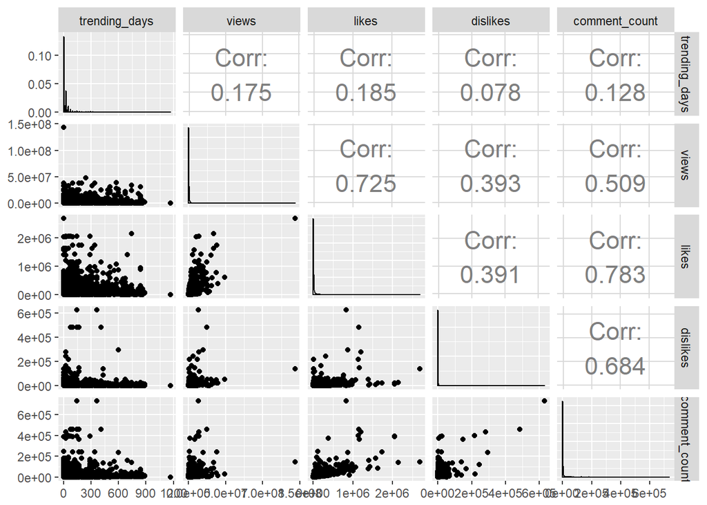

Since the data is heavily right skewed, we will take a log transformation. Lets have a look at the data after transformation.

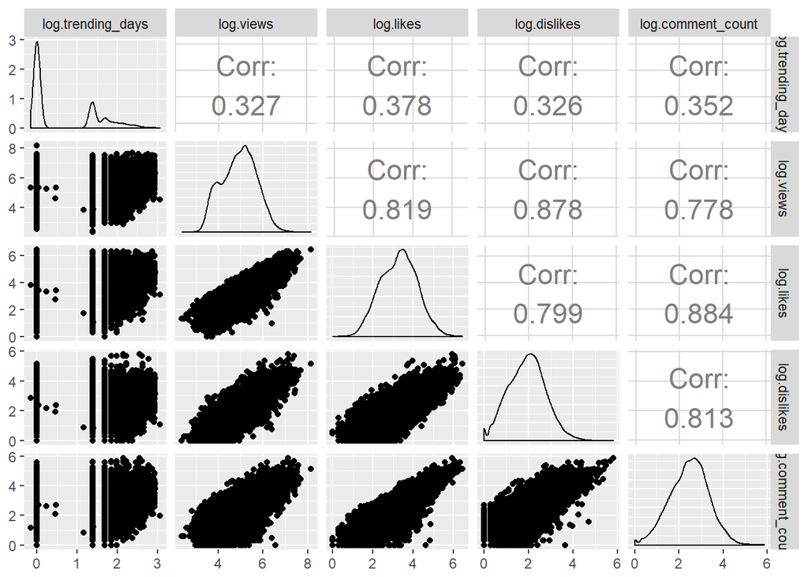

The distribution of data is improved after taking the log transformation except for trending days that still has ripple. Going forward, we will be using our log transformed data for analysis.

### Cross-Validation

We performed cross-validation for fitting and testing our model. We split the data into 80-20% train-test set.

As the data is ready for exploratory data analysis, we will go ahead and look at the relationship between other variables. We see that comment count has comparatively high collinearity with other variables. Hence we will not include it into our model.

Firstly lets look at the relationship between log likes and log number of views.

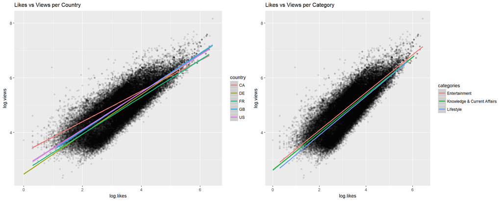

We can see that as the likes increase, the views tend to increase. In the first graph, until a certain period, Canada has the highest number of views compared to other countries. We can say there is an interaction between countries and likes. In the next graph, all the lines for various categories are almost overlapping. The categories do not look to have impact on the number of views a video might gain.

Similarly we will also look at the graph for log dislikes and number of views.

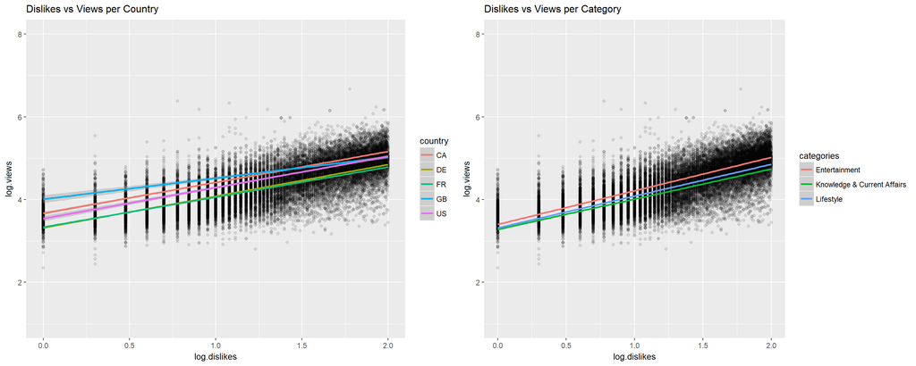

We will look now at the relationship of trending days vs likes to see if it affects the popularity of videos.

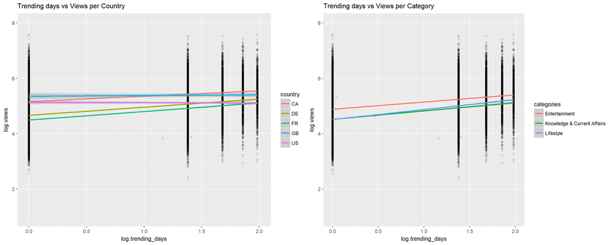

We observe the similar behaviour in trending days like we saw previously. Country and category has an effect and looks to have an interaction. We will retain these interactions in our model.

## Fitting a linear model

```
##
## Call:
## lm(formula = log.views ~ log.likes + log.dislikes + log.trending_days +
##     country + log.likes:country + log.dislikes:country + log.trending_days:country +
##     log.trending_days:categories, data = training_set)
##
## Residuals:
##      Min       1Q   Median       3Q      Max
## -1.82437 -0.21181  0.00606  0.21081  2.39395
##
## Coefficients:
##                                                          Estimate
## (Intercept)                                              3.383886
## log.likes                                                0.216054
## log.dislikes                                             0.509313
## log.trending_days                                        0.021464
## countryDE                                               -0.558439
## countryFR                                               -0.488617
## countryGB                                               -0.353941
## countryUS                                               -0.444871
## log.likes:countryDE                                      0.067393
## log.likes:countryFR                                      0.002543
## log.likes:countryGB                                      0.179240
## log.likes:countryUS                                      0.208445
## log.dislikes:countryDE                                   0.078001
## log.dislikes:countryFR                                   0.133365
## log.dislikes:countryGB                                  -0.113619
## log.dislikes:countryUS                                  -0.137009
## log.trending_days:countryDE                             -0.061477
## log.trending_days:countryFR                             -0.038448
## log.trending_days:countryGB                             -0.060510
## log.trending_days:countryUS                             -0.054115
## log.trending_days:categoriesKnowledge & Current Affairs -0.045114
## log.trending_days:categoriesLifestyle                   -0.022077
##                                                         Std. Error t value
## (Intercept)                                               0.013757 245.979
## log.likes                                                 0.005701  37.898
## log.dislikes                                              0.006348  80.226
## log.trending_days                                         0.004180   5.135
## countryDE                                                 0.017439 -32.023
```

[output cut: 31 more lines]

```
## log.dislikes:countryFR                                   < 2e-16 ***
## log.dislikes:countryGB                                  6.46e-13 ***
## log.dislikes:countryUS                                   < 2e-16 ***
## log.trending_days:countryDE                              < 2e-16 ***
## log.trending_days:countryFR                             2.10e-10 ***
## log.trending_days:countryGB                             1.87e-07 ***
## log.trending_days:countryUS                             4.37e-10 ***
## log.trending_days:categoriesKnowledge & Current Affairs  < 2e-16 ***
## log.trending_days:categoriesLifestyle                   4.40e-10 ***
## ---
## Signif. codes:  0 '***' 0.001 '**' 0.01 '*' 0.05 '.' 0.1 ' ' 1
##
## Residual standard error: 0.3237 on 46586 degrees of freedom
## Multiple R-squared:  0.827,  Adjusted R-squared:  0.827
## F-statistic: 1.061e+04 on 21 and 46586 DF,  p-value: < 2.2e-16
```

We see that our model fits well on our data. Also the residual error & r-squared values look pretty good. Lets fit the model on the test data and draw graphs.

```
## [1] 0.8208743
```

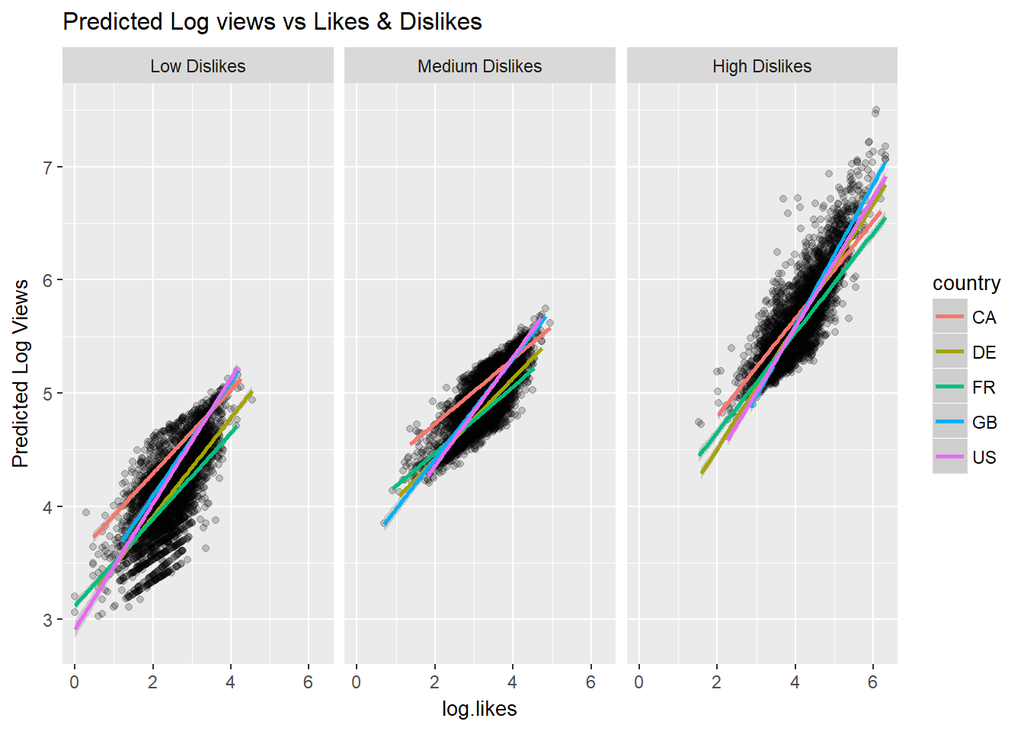

### Further Analysis

Now we will look at other aspects in our data sets that could give us little more insights about popularity of videos.

Lets check if a particular day of week gets higher number of views than other days for various categories.

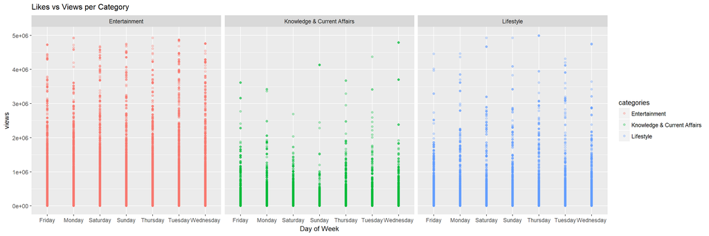

We can observe that the entertainment related videos stay trending on all days. Knowledge & current affairs related videos look to have low views on weekends(may be people want to just relax!). However Lifestyle videos go trending during weekends.

Now we will go aheadd and look how long videos mostly stay trending in various countries.

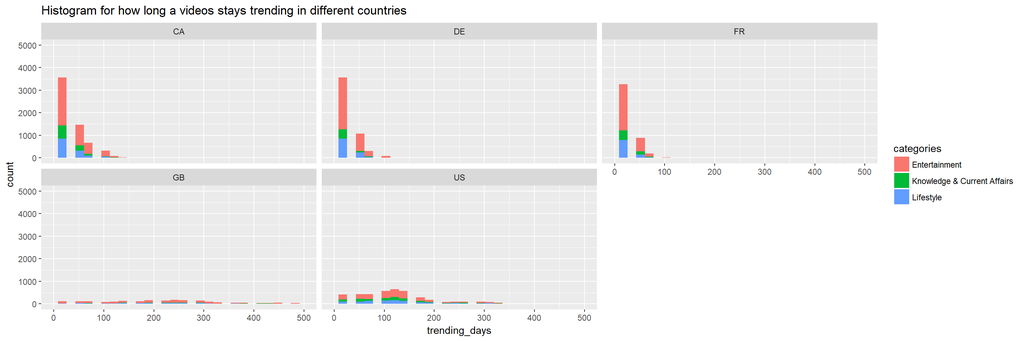

We can see that in CA,DE and France, most of the videos stay trending for a shorter durations of time (1-5 days). However in GB and US, most of the videos stay trending for a longer period of time.

## Future Work

Apart from numerical predictors, other factors that are significant in predicting popularity of video are video descriptions, titles and channels. We can perform text mining to perform such natural language processing. This can give us deeper insights of what words and sentences provoke the viewers to watch the videos. For now, This remains the future scope of our project.